# Universidad Politécnica Salesiana

## Presentación de modelo de red neuronal convolucional CNN

Descripción Dataset:

En la presente practica realizaremos la clasificación entre perros y gatos en base al conjunto de datos llamado Asirra disponible en kaggle consiste en 25,000 de imágenes que fueron clasificadas manualmente por personas de miles de refugios de animales dichas imágenes están etiquetadas como 1= perro, 0= gato , este conjunto de datos tiene cierto grado de complejidad porque las imágenes ofrecen distintos tonos de iluminación y distintas poses en las que se encuentran los perros como los gatos.

Enlace https://www.kaggle.com/c/dogs-vs-cats

# Se importan las librerias necesarias para la practica

```python
import numpy as np
import pandas as pd
import zipfile
import os
from keras.preprocessing.image import load_img, ImageDataGenerator
from keras.utils import to_categorical
from sklearn.model_selection import train_test_split
import matplotlib.pyplot as plt
import random
from keras.models import model_from_json

with zipfile.ZipFile("../input/dogs-vs-cats/train.zip", "r") as z:
    z.extractall(".")

with zipfile.ZipFile("../input/dogs-vs-cats/test1.zip", "r") as z:
    z.extractall(".")
```

## Descripción del Dataset</h>

Este conjunto de datos está conformado por 25.000 imágenes entonces en el siguiente bloque de código procederemos a obtener información de las etiquetas, recorriéndolas mediante un ciclo for, Luego procedemos a generar el dataframe para su posterior estudio.

```python
# Lista de las categorias
categorias = []
# Lista de archivos dentro de los datos de train
archivos = os.listdir("train")
# Bucle para obtener los nombres de los archivos (Etiquetas de salida)
for archivo in archivos:
    categoria = archivo.split('.')[0]
    if categoria == 'dog':
        categorias.append("dog")
    else:
        categorias.append("cat")

# Se crea un dataframe en base del nombre del archivo y la categoria (tipo de animal)
df = pd.DataFrame({
    'archivo': archivos,
    'categoria': categorias
})
print(categoria, '\n', df)
```

```
dog
              archivo categoria
0       cat.9523.jpg       cat
1       dog.5632.jpg       dog
2      dog.10226.jpg       dog
3       dog.2563.jpg       dog
4       cat.6973.jpg       cat
...              ...       ...
24995  cat.10553.jpg       cat
24996   cat.1578.jpg       cat
24997   dog.9561.jpg       dog
24998   dog.4382.jpg       dog
24999    dog.241.jpg       dog

[25000 rows x 2 columns]
```

## Splitting Del Dataset

Separamos el conjunto de train y test, luego indicamos que los índices o puteros estén en el comienzo de los dataframes.

```python
# Separamos dos conjuntos, train(80% del dataset) y test(20%).
train, test = train_test_split(df, test_size=0.20, random_state=42)

# Reseteamos los index para vayan al comienzo de daatframe.
train = train.reset_index(drop=True)
test = test.reset_index(drop=True)

# Imprimimos el tamano de los dataframes.
print(train.shape, '<-->', test.shape)
```

```
(20000, 2) <--> (5000, 2)
```

## Preprocesamiento De Los Datos

Establecemos un conjunto de parámetros para generar más imágenes partiendo de las que ya tenemos, buscando generar más datos para que la red neuronal entrene con mas información, estos parámetros se fijan en la variable train_image_data. Luego hacemos uso del método flow_from_dataframe() donde especificamos los parámetros anteriores y hacemos referencia a el apartado de train del dataset anterior, pro ultimo procedemos a realizar una normalización de los valores de los pixeles.

Las imágenes de este conjunto de datos tienen la dimensión de 128x128 y contiene tres canales.

```python
# Generador De Entrenamiento (Preprocesamiento de las imagenes)
TAM_IMG = (128, 128)
"""
Generamos nuevas imagenes en base a las pre existentes, por ejmplo, podemos cambiar el rango de rotacion,
cortamos la imagen, hacemos zoom, volteamos, entre otras tecnicas para que de esta manera podamos tener
una mayor cantidad de imagenes para entrenar y hacer el testing.

"""
train_image_data = ImageDataGenerator(
    rotation_range = 15,
    rescale = 1./255,
    shear_range = 0.1,
    zoom_range=0.2,
    horizontal_flip = True,
    width_shift_range = 0.1,
    height_shift_range = 0.1
)

# Procedemos ha generar las imagenes y preprocesarlas.
train_generador = train_image_data.flow_from_dataframe(
    train,
    'train/',
    x_col = 'archivo',
    y_col = 'categoria',
    target_size = TAM_IMG,
    class_mode = 'categorical',
    batch_size = 32
)

# Escalamos la imagen diviendo cada pixel para 255.
test_image_data = ImageDataGenerator(rescale=1./255)
test_generador = test_image_data.flow_from_dataframe(
    test,
    'train/',
    x_col = 'archivo',
    y_col = 'categoria',
    target_size = TAM_IMG,
    class_mode = 'categorical',
    batch_size = 32
)
```

```
Found 20000 validated image filenames belonging to 2 classes.
Found 5000 validated image filenames belonging to 2 classes.
```

## Modelo De La Red Neuronal Convolucional

En la capa de salida tenemos solamente dos neuronas porque en este caso de estudio vamos a clasificar dos clases (perros y gatos) donde aplicamos una activación softmax.

El modelo general tendrá una función de perdida categorical_crossentropy en conjunto con un optimizador rmsprop.

```python
# Modelo para el entrenamiento
from keras.models import Sequential
from keras.layers import Conv2D, MaxPooling2D, Dropout, Flatten, Dense, Activation, BatchNormalization

modelo = Sequential()

modelo.add(Conv2D(32, (3, 3), activation='relu', input_shape=(128, 128, 3)))
modelo.add(BatchNormalization())
modelo.add(MaxPooling2D(pool_size=(2, 2)))
modelo.add(Dropout(0.25))

modelo.add(Conv2D(64, (3, 3), activation='relu'))
modelo.add(BatchNormalization())
modelo.add(MaxPooling2D(pool_size=(2, 2)))
modelo.add(Dropout(0.25))

modelo.add(Conv2D(128, (3, 3), activation='relu'))
modelo.add(BatchNormalization())
modelo.add(MaxPooling2D(pool_size=(2, 2)))
modelo.add(Dropout(0.25))

modelo.add(Conv2D(128, (3, 3), activation='relu'))
modelo.add(BatchNormalization())
modelo.add(MaxPooling2D(pool_size=(2, 2)))
modelo.add(Dropout(0.25))

modelo.add(Flatten())
modelo.add(Dense(512, activation = 'relu'))
modelo.add(BatchNormalization())
modelo.add(Dropout(0.5))
modelo.add(Dense(2, activation='softmax'))

modelo.compile(loss='categorical_crossentropy', optimizer='rmsprop', metrics=['accuracy'])
modelo.summary()
```

```
Model: "sequential_3"
_________________________________________________________________
Layer (type)                 Output Shape              Param #
=================================================================
conv2d_6 (Conv2D)            (None, 126, 126, 32)      896
_________________________________________________________________
batch_normalization_8 (Batch (None, 126, 126, 32)      128
_________________________________________________________________
max_pooling2d_6 (MaxPooling2 (None, 63, 63, 32)        0
_________________________________________________________________
dropout_8 (Dropout)          (None, 63, 63, 32)        0
_________________________________________________________________
conv2d_7 (Conv2D)            (None, 61, 61, 64)        18496
_________________________________________________________________
batch_normalization_9 (Batch (None, 61, 61, 64)        256
_________________________________________________________________
max_pooling2d_7 (MaxPooling2 (None, 30, 30, 64)        0
_________________________________________________________________
dropout_9 (Dropout)          (None, 30, 30, 64)        0
_________________________________________________________________
conv2d_8 (Conv2D)            (None, 28, 28, 128)       73856
_________________________________________________________________
batch_normalization_10 (Batc (None, 28, 28, 128)       512
_________________________________________________________________
max_pooling2d_8 (MaxPooling2 (None, 14, 14, 128)       0
_________________________________________________________________
dropout_10 (Dropout)         (None, 14, 14, 128)       0
_________________________________________________________________
conv2d_9 (Conv2D)            (None, 12, 12, 128)       147584
_________________________________________________________________
batch_normalization_11 (Batc (None, 12, 12, 128)       512
_________________________________________________________________
max_pooling2d_9 (MaxPooling2 (None, 6, 6, 128)         0
_________________________________________________________________
dropout_11 (Dropout)         (None, 6, 6, 128)         0
_________________________________________________________________
flatten_3 (Flatten)          (None, 4608)              0
_________________________________________________________________
dense_5 (Dense)              (None, 512)               2359808
_________________________________________________________________
batch_normalization_12 (Batc (None, 512)               2048
_________________________________________________________________
dropout_12 (Dropout)         (None, 512)               0
_________________________________________________________________
dense_6 (Dense)              (None, 2)                 1026
=================================================================
Total params: 2,605,122
Trainable params: 2,603,394
Non-trainable params: 1,728
_________________________________________________________________
```

## Entrenamiento De La CNN

```python
train_shape = train.shape[0]
test_shape = test.shape[0]

history = modelo.fit_generator(
    train_generador,
    epochs = 25,
    validation_data = test_generador,
    validation_steps = test_shape//64,
    steps_per_epoch = train_shape//64,
)
```

## Obtención De Los Resultados

```python
accuracy_training = history.history['accuracy']
accuracy_testing = history.history['val_accuracy']
epochs = 26
```

```python
plt.rcParams["figure.figsize"] = (12,8)
plt.grid()
plt.plot(accuracy_training, color='b', label="Training accuracy")
plt.xticks(np.arange(1, epochs, 1))
plt.xlabel('EPOCHS')
plt.ylabel('Accuracy en Training')
plt.tight_layout()
plt.show()
```

[output not shown]

```python
plt.rcParams["figure.figsize"] = (12,8)
plt.grid()
plt.plot(accuracy_testing, color='r')
plt.xticks(np.arange(1, epochs, 1))
plt.xlabel('EPOCHS')
plt.ylabel('Accuracy en Testing')
plt.tight_layout()
plt.show()
```

[output not shown]

## Almacenamiento Del Modelo y Pesos

Declaramos las funciones que nos permitirán guardar y cargar los modelos de la red neuronal y también guardar los pesos de la misma.

```python
def guardar_pesos(nombre_archivo='pesos.h5'):
    modelo.save_weights(nombre_archivo)

def guardar_modelo(nombre_archivo='modelo.json'):
    modelo_json = modelo.to_json()
    with open(nombre_archivo, "w") as json_file:
        json_file.write(modelo_json)

def cargar_modelo(archivo_modelo='modelo.json', archivo_pesos='pesos.h5'):
    with open(archivo_modelo, 'r') as f:
        modelo = model_from_json(f.read())

    modelo.load_weights(archivo_pesos)

    return modelo

modelo = cargar_modelo(archivo_modelo='../input/cats-v-dogs-leo/modelo.json', archivo_pesos='../input/cats-v-dogs-leo/pesos.h5')
```

## Listado De Archivos Para Testing

```python
archivos_test = os.listdir("test1")
test1 = pd.DataFrame({
    'archivo': archivos_test
})
muestras = test1.shape[0]
print(muestras)
```

```
12500
```

## Preprocesamiento De Los Datos Para Testing

```python
# Preprocesamiento y generador de imagenes para testing.
TAM_IMG = (128, 128)

test_generador = ImageDataGenerator(rescale=1./255)
test_gen = test_generador.flow_from_dataframe(
    test1,
    'test1',
    x_col = 'archivo',
    y_col = None,
    class_mode = None,
    target_size = TAM_IMG,
    batch_size = 32,
    shuffle = False
)
```

```
Found 12500 validated image filenames.
```

## Predicción De Los Datos De Testing

```python
prediccion = modelo.predict_generator(test_gen, steps=np.ceil(muestras/32))
```

## Agrupamiento De Los Resultados

```python
test1['categoria'] = np.argmax(prediccion, axis = 1)
label_map = dict((v, k) for k, v in train_generador.class_indices.items())
test1['categoria'] = test1['categoria'].replace(label_map)
```

## Predicción De Resultados A Través De URL's

Declaramos una función que nos permite predecir si lo que representa una imagen corresponde a un perro o gato, como parámetro recibimos la url de la imagen a clasificar y como resultado obtenemos imprimimos la imagen ingresada acompañada del porcentaje de precisión con la que la red neuronal determina para esa imagen.

```
PERRO, probabilidad:  50.75%
PERRO, probabilidad:  51.47%
```

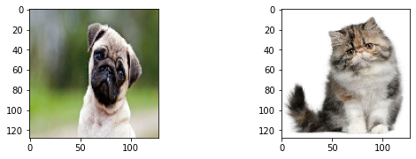

```python
from io import BytesIO
from six.moves import urllib
from keras.preprocessing import image

TAM_IMG = (128, 128)


def predecir_img(URL):
    img = None
    with urllib.request.urlopen(URL) as url:
        img = load_img(BytesIO(url.read()), target_size=(128, 128))
    imagen = img
    img = image.img_to_array(img)
    img = np.expand_dims(img, axis=0)
    img /= 255
    resultado = modelo.predict(img)
    val0 = resultado.tolist()[0][0]
    val1 = resultado.tolist()[0][1]
    if val0 > val1:
        return ('GATO', val0, imagen)
    elif val1 > val0:
        return ('PERRO', val1, imagen)

plt.figure(figsize=(12, 12))

animal, accuracy, imagen = predecir_img('https://static.iris.net.co/semana/upload/images/2019/6/18/620159_1.jpg')
print(animal +', probabilidad: ', str(round(accuracy*100, 2))+'%')
plt.subplot(5, 3, 1)
plt.imshow(imagen)

animal, accuracy, imagen = predecir_img('https://www.petdarling.com/articulos/wp-content/uploads/2014/08/gatos-persa.jpg?width=1200&enable=upscale')
print(animal +', probabilidad: ', str(round(accuracy*100, 2))+'%')
plt.subplot(5, 3, 2)
plt.imshow(imagen)

plt.tight_layout()
plt.show()
```

### Predicción De Imágenes A Través De Imágenes De Testing

Método donde se puede visualizar una imagen del dataset determinando por un índice.

```
Imagen: 	 922.jpg
Valor minimo: 	 0.0
Valor maximo: 	 255.0
Shape: 	 (128, 128, 3)
% Prediccion: 	 52.77
ETIQUETA 	 PERRO
```

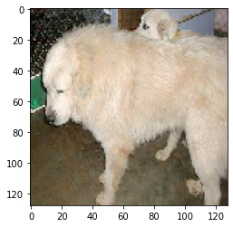

```python
# METODO
from keras.preprocessing import image

def display_stats(sample_id = 5):
    train_len = len([name for name in os.listdir('test1')])

    if sample_id < train_len:
        names = []
        datos = dict()
        for name in os.listdir('test1'):
            names.append(name)
        file = load_img('test1/'+ names[sample_id], target_size=(128, 128))
        datos['Imagen:'] = names[sample_id]
        img = image.img_to_array(file)
        datos['Valor minimo:'] = np.min(img)
        datos['Valor maximo:'] = np.max(img)
        datos['Shape:'] = img.shape
        img = np.expand_dims(img, axis=0)
        img /= 255

        resultado = modelo.predict(img)
        val0 = resultado.tolist()[0][0]
        val1 = resultado.tolist()[0][1]
        if val0 > val1:
            #return ('GATO', val0, imagen)
            datos['% Prediccion:'] = round(val0*100, 2)
            datos['ETIQUETA'] = 'GATO'
        elif val1 > val0:
            datos['% Prediccion:'] = round(val1*100, 2)
            datos['ETIQUETA'] = 'PERRO'
        for x, y in datos.items():
            print(x, '\t', y)
        print()
        plt.imshow(file)

# EJEMPLO PERRO
display_stats(27)
# EJEMPLO GATO
#display_stats(98)
```

# Concluciones:

- En cuanto a lo elaborado en esta práctica aprendemos sobre el manejo de imágenes para ingresar dicha información en una red neuronal aplicando reducción de dimensiones y capas que obtienen la información más relevante de las imágenes.
- Frente a los resultados obtenidos podemos establecer que en determinados casos una optimización de parámetros no refleja mejora en la precisión de una red neuronal.
- En particular las redes neuronales tienen mejor desempeño en comparación con otros algoritmos ya que simulan el comportamiento de las redes neuronales humanas.